# temp

# Reading in data

The following code reads the data and performs some basic necessary conversions.

```r
# read in data
data.dir <- "../data/"
setwd(data.dir)
ames.full <- read.csv(file = 'AmesHousing.txt', sep = "\t")

# dimensions
dims <- dim(ames.full)

# conversions
names(ames.full)
```

```
##  [1] "Order"           "PID"             "MS.SubClass"     "MS.Zoning"
##  [5] "Lot.Frontage"    "Lot.Area"        "Street"          "Alley"
##  [9] "Lot.Shape"       "Land.Contour"    "Utilities"       "Lot.Config"
## [13] "Land.Slope"      "Neighborhood"    "Condition.1"     "Condition.2"
## [17] "Bldg.Type"       "House.Style"     "Overall.Qual"    "Overall.Cond"
## [21] "Year.Built"      "Year.Remod.Add"  "Roof.Style"      "Roof.Matl"
## [25] "Exterior.1st"    "Exterior.2nd"    "Mas.Vnr.Type"    "Mas.Vnr.Area"
## [29] "Exter.Qual"      "Exter.Cond"      "Foundation"      "Bsmt.Qual"
## [33] "Bsmt.Cond"       "Bsmt.Exposure"   "BsmtFin.Type.1"  "BsmtFin.SF.1"
## [37] "BsmtFin.Type.2"  "BsmtFin.SF.2"    "Bsmt.Unf.SF"     "Total.Bsmt.SF"
## [41] "Heating"         "Heating.QC"      "Central.Air"     "Electrical"
## [45] "X1st.Flr.SF"     "X2nd.Flr.SF"     "Low.Qual.Fin.SF" "Gr.Liv.Area"
## [49] "Bsmt.Full.Bath"  "Bsmt.Half.Bath"  "Full.Bath"       "Half.Bath"
## [53] "Bedroom.AbvGr"   "Kitchen.AbvGr"   "Kitchen.Qual"    "TotRms.AbvGrd"
## [57] "Functional"      "Fireplaces"      "Fireplace.Qu"    "Garage.Type"
## [61] "Garage.Yr.Blt"   "Garage.Finish"   "Garage.Cars"     "Garage.Area"
## [65] "Garage.Qual"     "Garage.Cond"     "Paved.Drive"     "Wood.Deck.SF"
## [69] "Open.Porch.SF"   "Enclosed.Porch"  "X3Ssn.Porch"     "Screen.Porch"
## [73] "Pool.Area"       "Pool.QC"         "Fence"           "Misc.Feature"
## [77] "Misc.Val"        "Mo.Sold"         "Yr.Sold"         "Sale.Type"
## [81] "Sale.Condition"  "SalePrice"
```

```r
for (name in names(ames.full)) {
  if (typeof(ames.full[,name]) == "character"){
    ames.full[,name] <- as.factor(ames.full[,name])
  }
}
ames.full$Overall.Qual <- as.numeric(ames.full$Overall.Qual)
ames.full$Overall.Cond <- as.numeric(ames.full$Overall.Cond)
```

# Data cleanup & preparation

The following code displays the summary of the full data frame and removes some columns with a lot of Na values.

```r
summary(ames.full)
```

```
##      Order             PID             MS.SubClass       MS.Zoning
##  Min.   :   1.0   Min.   :5.263e+08   Min.   : 20.00   A (agr):   2
##  1st Qu.: 733.2   1st Qu.:5.285e+08   1st Qu.: 20.00   C (all):  25
##  Median :1465.5   Median :5.355e+08   Median : 50.00   FV     : 139
##  Mean   :1465.5   Mean   :7.145e+08   Mean   : 57.39   I (all):   2
##  3rd Qu.:2197.8   3rd Qu.:9.072e+08   3rd Qu.: 70.00   RH     :  27
##  Max.   :2930.0   Max.   :1.007e+09   Max.   :190.00   RL     :2273
##                                                        RM     : 462
##   Lot.Frontage       Lot.Area       Street      Alley      Lot.Shape
##  Min.   : 21.00   Min.   :  1300   Grvl:  12   Grvl: 120   IR1: 979
##  1st Qu.: 58.00   1st Qu.:  7440   Pave:2918   Pave:  78   IR2:  76
##  Median : 68.00   Median :  9436               NA's:2732   IR3:  16
##  Mean   : 69.22   Mean   : 10148                           Reg:1859
##  3rd Qu.: 80.00   3rd Qu.: 11555
##  Max.   :313.00   Max.   :215245
##  NA's   :490
##  Land.Contour  Utilities      Lot.Config   Land.Slope  Neighborhood
##  Bnk: 117     AllPub:2927   Corner : 511   Gtl:2789   NAmes  : 443
##  HLS: 120     NoSeWa:   1   CulDSac: 180   Mod: 125   CollgCr: 267
##  Low:  60     NoSewr:   2   FR2    :  85   Sev:  16   OldTown: 239
##  Lvl:2633                   FR3    :  14              Edwards: 194
##                             Inside :2140              Somerst: 182
##                                                       NridgHt: 166
##                                                       (Other):1439
##   Condition.1    Condition.2    Bldg.Type     House.Style    Overall.Qual
##  Norm   :2522   Norm   :2900   1Fam  :2425   1Story :1481   Min.   : 1.000
##  Feedr  : 164   Feedr  :  13   2fmCon:  62   2Story : 873   1st Qu.: 5.000
##  Artery :  92   Artery :   5   Duplex: 109   1.5Fin : 314   Median : 6.000
##  RRAn   :  50   PosA   :   4   Twnhs : 101   SLvl   : 128   Mean   : 6.095
##  PosN   :  39   PosN   :   4   TwnhsE: 233   SFoyer :  83   3rd Qu.: 7.000
##  RRAe   :  28   RRNn   :   2                 2.5Unf :  24   Max.   :10.000
##  (Other):  35   (Other):   2                 (Other):  27
##   Overall.Cond     Year.Built   Year.Remod.Add   Roof.Style     Roof.Matl
##  Min.   :1.000   Min.   :1872   Min.   :1950   Flat   :  20   CompShg:2887
##  1st Qu.:5.000   1st Qu.:1954   1st Qu.:1965   Gable  :2321   Tar&Grv:  23
##  Median :5.000   Median :1973   Median :1993   Gambrel:  22   WdShake:   9
##  Mean   :5.563   Mean   :1971   Mean   :1984   Hip    : 551   WdShngl:   7
##  3rd Qu.:6.000   3rd Qu.:2001   3rd Qu.:2004   Mansard:  11   ClyTile:   1
##  Max.   :9.000   Max.   :2010   Max.   :2010   Shed   :   5   Membran:   1
##                                                               (Other):   2
```

[output cut: 89 more lines]

```
##  Min.   :    0.00   Min.   : 1.000   Min.   :2006   WD     :2536
##  1st Qu.:    0.00   1st Qu.: 4.000   1st Qu.:2007   New    : 239
##  Median :    0.00   Median : 6.000   Median :2008   COD    :  87
##  Mean   :   50.63   Mean   : 6.216   Mean   :2008   ConLD  :  26
##  3rd Qu.:    0.00   3rd Qu.: 8.000   3rd Qu.:2009   CWD    :  12
##  Max.   :17000.00   Max.   :12.000   Max.   :2010   ConLI  :   9
##                                                     (Other):  21
##  Sale.Condition   SalePrice
##  Abnorml: 190   Min.   : 12789
##  AdjLand:  12   1st Qu.:129500
##  Alloca :  24   Median :160000
##  Family :  46   Mean   :180796
##  Normal :2413   3rd Qu.:213500
##  Partial: 245   Max.   :755000
##
```

```r
# count NA values and get column types
nac <- sapply(ames.full, function(x) sum(is.na(x)))
for (i in 1:length(nac)) {
 cat(names(nac[i]), "\t", nac[[i]], "\t", class(ames.full[1,i]), "\n")
}
```

```
## Order     0   integer
## PID   0   integer
## MS.SubClass   0   integer
## MS.Zoning     0   factor
## Lot.Frontage      490     integer
## Lot.Area      0   integer
## Street    0   factor
## Alley     2732    factor
## Lot.Shape     0   factor
## Land.Contour      0   factor
## Utilities     0   factor
## Lot.Config    0   factor
## Land.Slope    0   factor
## Neighborhood      0   factor
## Condition.1   0   factor
## Condition.2   0   factor
## Bldg.Type     0   factor
## House.Style   0   factor
## Overall.Qual      0   numeric
## Overall.Cond      0   numeric
## Year.Built    0   integer
## Year.Remod.Add    0   integer
## Roof.Style    0   factor
## Roof.Matl     0   factor
## Exterior.1st      0   factor
## Exterior.2nd      0   factor
## Mas.Vnr.Type      0   factor
## Mas.Vnr.Area      23      integer
## Exter.Qual    0   factor
## Exter.Cond    0   factor
## Foundation    0   factor
## Bsmt.Qual     79      factor
## Bsmt.Cond     79      factor
## Bsmt.Exposure     79      factor
## BsmtFin.Type.1    79      factor
## BsmtFin.SF.1      1   integer
## BsmtFin.Type.2    79      factor
## BsmtFin.SF.2      1   integer
## Bsmt.Unf.SF   1   integer
## Total.Bsmt.SF     1   integer
```

[output cut: 27 more lines]

```
## Wood.Deck.SF      0   integer
## Open.Porch.SF     0   integer
## Enclosed.Porch    0   integer
## X3Ssn.Porch   0   integer
## Screen.Porch      0   integer
## Pool.Area     0   integer
## Pool.QC   2917    factor
## Fence     2358    factor
## Misc.Feature      2824    factor
## Misc.Val      0   integer
## Mo.Sold   0   integer
## Yr.Sold   0   integer
## Sale.Type     0   factor
## Sale.Condition    0   factor
## SalePrice     0   integer
```

We remove columns that contain NA values for more than 10% of the observations.

```r
n = 0
for (i in 1:length(nac)) {
  na.pct <- nac[[i]] / dims[1]
  if (na.pct > 0.10) {
    n <- n + 1
    cat(na.pct, "\t", names(nac[i]), "\n")
  }
}
```

```
## 0.1672355     Lot.Frontage
## 0.9324232     Alley
## 0.4853242     Fireplace.Qu
## 0.9955631     Pool.QC
## 0.8047782     Fence
## 0.9638225     Misc.Feature
```

```r
# Construct a vector of columns to remove
f <- function(col.name) {
  na.pct = sum(is.na(ames.full[col.name])) / dims[1]
  if (na.pct>0.10){
    return(TRUE)
  } else {
    return(FALSE)
  }
}

cols.to.remove <- names(ames.full)[sapply(names(ames.full), f)]
```

We will remove these columns, and also remove “order” and “pid” which have no predictive power.

```r
ames <- ames.full[, -which(names(ames.full) %in% cols.to.remove)]
ames <- ames[, -which(names(ames) %in% c("Order", "PID"))]
```

```r
names(ames)
```

```
##  [1] "MS.SubClass"     "MS.Zoning"       "Lot.Area"        "Street"
##  [5] "Lot.Shape"       "Land.Contour"    "Utilities"       "Lot.Config"
##  [9] "Land.Slope"      "Neighborhood"    "Condition.1"     "Condition.2"
## [13] "Bldg.Type"       "House.Style"     "Overall.Qual"    "Overall.Cond"
## [17] "Year.Built"      "Year.Remod.Add"  "Roof.Style"      "Roof.Matl"
## [21] "Exterior.1st"    "Exterior.2nd"    "Mas.Vnr.Type"    "Mas.Vnr.Area"
## [25] "Exter.Qual"      "Exter.Cond"      "Foundation"      "Bsmt.Qual"
## [29] "Bsmt.Cond"       "Bsmt.Exposure"   "BsmtFin.Type.1"  "BsmtFin.SF.1"
## [33] "BsmtFin.Type.2"  "BsmtFin.SF.2"    "Bsmt.Unf.SF"     "Total.Bsmt.SF"
## [37] "Heating"         "Heating.QC"      "Central.Air"     "Electrical"
## [41] "X1st.Flr.SF"     "X2nd.Flr.SF"     "Low.Qual.Fin.SF" "Gr.Liv.Area"
## [45] "Bsmt.Full.Bath"  "Bsmt.Half.Bath"  "Full.Bath"       "Half.Bath"
## [49] "Bedroom.AbvGr"   "Kitchen.AbvGr"   "Kitchen.Qual"    "TotRms.AbvGrd"
## [53] "Functional"      "Fireplaces"      "Garage.Type"     "Garage.Yr.Blt"
## [57] "Garage.Finish"   "Garage.Cars"     "Garage.Area"     "Garage.Qual"
## [61] "Garage.Cond"     "Paved.Drive"     "Wood.Deck.SF"    "Open.Porch.SF"
## [65] "Enclosed.Porch"  "X3Ssn.Porch"     "Screen.Porch"    "Pool.Area"
## [69] "Misc.Val"        "Mo.Sold"         "Yr.Sold"         "Sale.Type"
## [73] "Sale.Condition"  "SalePrice"
```

We will drop the rest of the observations that contain Na’s.

```r
ames <- ames[complete.cases(ames), ]
```

We have removed the following percentage of the observations:

```r
cat((1 - dim(ames)[1] / dim(ames.full)[1]) * 100, " %")
```

```
## 8.430034  %
```

# Finiding the normal linear model that best explains the variability in SalePrice

### Full model (unnecessarily complicated)

```r
fit <- lm(SalePrice ~ ., data=ames)
summary(fit)
```

```
##
## Call:
## lm(formula = SalePrice ~ ., data = ames)
##
## Residuals:
##     Min      1Q  Median      3Q     Max
## -310293  -10153     -72    9345  161436
##
## Coefficients: (3 not defined because of singularities)
##                         Estimate Std. Error t value Pr(>|t|)
## (Intercept)           -4.975e+05  7.614e+05  -0.653 0.513541
## MS.SubClass           -9.088e+01  5.912e+01  -1.537 0.124366
## MS.ZoningFV            2.035e+04  9.643e+03   2.110 0.034973 *
## MS.ZoningI (all)       1.164e+04  2.728e+04   0.427 0.669600
## MS.ZoningRH            2.469e+04  1.014e+04   2.434 0.015018 *
## MS.ZoningRL            2.079e+04  8.551e+03   2.431 0.015128 *
## MS.ZoningRM            1.630e+04  8.097e+03   2.013 0.044270 *
## Lot.Area               6.618e-01  8.976e-02   7.373 2.28e-13 ***
## StreetPave             2.165e+04  9.953e+03   2.176 0.029678 *
## Lot.ShapeIR2           4.773e+03  3.105e+03   1.537 0.124391
## Lot.ShapeIR3           1.941e+03  6.793e+03   0.286 0.775061
## Lot.ShapeReg           1.447e+03  1.173e+03   1.234 0.217334
## Land.ContourHLS        1.436e+04  3.733e+03   3.847 0.000123 ***
## Land.ContourLow       -5.482e+03  4.946e+03  -1.109 0.267753
## Land.ContourLvl        8.933e+03  2.832e+03   3.154 0.001629 **
## UtilitiesNoSeWa       -2.510e+04  2.527e+04  -0.993 0.320651
## UtilitiesNoSewr       -1.595e+04  2.486e+04  -0.642 0.521207
## Lot.ConfigCulDSac      6.232e+03  2.349e+03   2.653 0.008033 **
## Lot.ConfigFR2         -7.726e+03  3.132e+03  -2.467 0.013688 *
## Lot.ConfigFR3         -4.705e+03  6.853e+03  -0.687 0.492405
## Lot.ConfigInside      -3.838e+02  1.304e+03  -0.294 0.768531
## Land.SlopeMod          8.090e+03  2.945e+03   2.747 0.006051 **
## Land.SlopeSev         -2.790e+04  8.999e+03  -3.100 0.001955 **
## NeighborhoodBlueste    4.595e+02  9.860e+03   0.047 0.962835
## NeighborhoodBrDale     6.064e+03  8.266e+03   0.734 0.463314
## NeighborhoodBrkSide   -6.281e+03  7.050e+03  -0.891 0.373074
## NeighborhoodClearCr   -1.098e+04  7.011e+03  -1.567 0.117334
## NeighborhoodCollgCr   -1.205e+04  5.442e+03  -2.214 0.026942 *
## NeighborhoodCrawfor    3.701e+03  6.266e+03   0.591 0.554817
## NeighborhoodEdwards   -2.294e+04  5.970e+03  -3.843 0.000125 ***
```

[output cut: 203 more lines]

```
## Sale.TypeNew           1.105e+04  1.086e+04   1.017 0.309082
## Sale.TypeOth           2.427e+04  1.225e+04   1.981 0.047653 *
## Sale.TypeVWD          -3.265e+03  2.438e+04  -0.134 0.893482
## Sale.TypeWD            2.347e+03  2.987e+03   0.786 0.432174
## Sale.ConditionAdjLand  3.065e+04  1.073e+04   2.857 0.004307 **
## Sale.ConditionAlloca   7.521e+03  7.676e+03   0.980 0.327270
## Sale.ConditionFamily   1.510e+03  4.178e+03   0.361 0.717769
## Sale.ConditionNormal   6.329e+03  2.223e+03   2.847 0.004452 **
## Sale.ConditionPartial  5.931e+03  1.048e+04   0.566 0.571447
## ---
## Signif. codes:  0 '***' 0.001 '**' 0.01 '*' 0.05 '.' 0.1 ' ' 1
##
## Residual standard error: 23350 on 2444 degrees of freedom
## Multiple R-squared:  0.9213, Adjusted R-squared:  0.9136
## F-statistic: 120.2 on 238 and 2444 DF,  p-value: < 2.2e-16
```

Note: Total.Bsmt.SF, Gr.Liv.Area produce NAs for the coeffs because they are precise linear combinations of other features. Remove them? Keep *them* and remove the other features? We can start by removing *them*.

```r
ames <- ames[, -which(names(ames) %in% c("Total.Bsmt.SF", "Gr.Liv.Area"))]
```

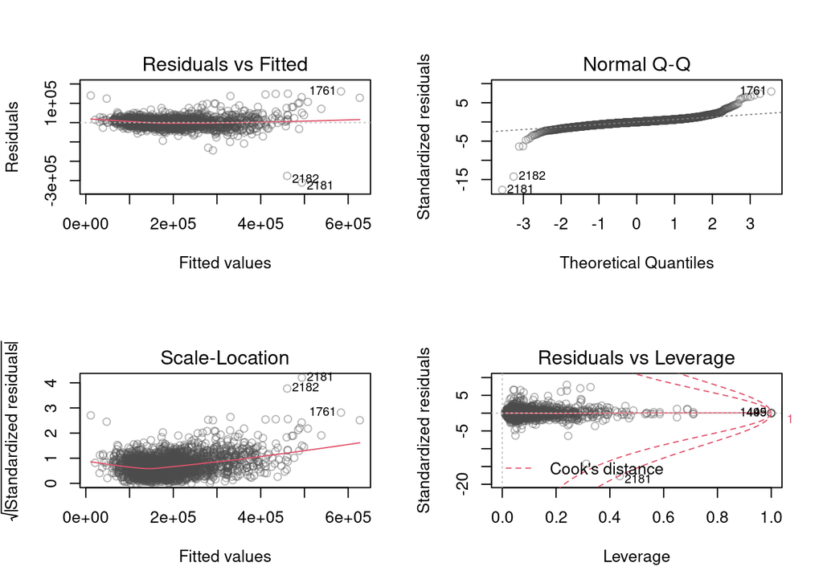

```r
par(mfrow=c(2,2))
plot(fit, col = point.col)
```

We will manually remove some outliers using this model, and repeat the model fitting.

```r
ids <- which(  (abs(residuals(fit))>1.5e5) | (hatvalues(fit)>0.99) )
ids
```

```
##  105  211  337  445  664  956 1014 1314 1402 1499 1578 1611 1761 1862 1871 1908
##  102  198  309  416  626  876  931 1212 1286 1374 1438 1468 1616 1710 1719 1750
## 1916 2044 2070 2181 2182 2240 2257 2299 2341 2504 2766 2789
## 1758 1876 1901 2004 2005 2053 2068 2104 2144 2298 2538 2561
```

```r
ames <- ames[-ids, ]
```

Since we have removed data, we might have ended up with factors with unused levels. This, among other issues, can cause [problems](https://stackoverflow.com/questions/44200195/how-to-debug-contrasts-can-be-applied-only-to-factors-with-2-or-more-levels-er). We have to reformat the factor data, and [drop unused factor levels](https://stat.ethz.ch/R-manual/R-devel/library/base/html/droplevels.html).

```r
ames <- droplevels(ames)
```

Now we might have ended up with factors that contain a single level.

```r
for (name in names(ames)) {
  if (!is.null(levels(ames[,name]))) {
    if (length(levels(ames[,name])) == 1) {
      cat('~~~\n')
    }
    cat(length(levels(ames[,name])), ' ', name, '\n')
    if (length(levels(ames[,name])) == 1) {
      cat('~~~\n')
    }
  }
}
```

```
## 5   MS.Zoning
## 2   Street
## 4   Lot.Shape
## 4   Land.Contour
## ~~~
## 1   Utilities
## ~~~
## 5   Lot.Config
## 3   Land.Slope
## 26   Neighborhood
## 9   Condition.1
## 6   Condition.2
## 5   Bldg.Type
## 8   House.Style
## 6   Roof.Style
```

[output cut: 25 more lines]

```r
levels(ames[,"Utilities"])
```

```
## [1] "AllPub"
```

```r
ames <- ames[, -which(names(ames) %in% c("Utilities"))]
```

```r
fit <- lm(SalePrice ~ ., data=ames)
summary(fit)
```

```
##
## Call:
## lm(formula = SalePrice ~ ., data = ames)
##
## Residuals:
##     Min      1Q  Median      3Q     Max
## -143040   -9324     116    9384  141746
##
## Coefficients:
##                         Estimate Std. Error t value Pr(>|t|)
## (Intercept)            2.354e+05  6.569e+05   0.358 0.720132
## MS.SubClass           -8.290e+01  5.117e+01  -1.620 0.105378
## MS.ZoningFV            2.373e+04  8.348e+03   2.843 0.004511 **
## MS.ZoningRH            2.460e+04  8.781e+03   2.802 0.005120 **
## MS.ZoningRL            2.031e+04  7.401e+03   2.744 0.006118 **
## MS.ZoningRM            1.356e+04  7.010e+03   1.935 0.053102 .
## Lot.Area               8.184e-01  7.797e-02  10.495  < 2e-16 ***
## StreetPave             2.640e+04  8.617e+03   3.063 0.002214 **
## Lot.ShapeIR2           1.780e+03  2.690e+03   0.661 0.508356
## Lot.ShapeIR3          -2.515e+03  5.883e+03  -0.428 0.669023
## Lot.ShapeReg           8.652e+02  1.016e+03   0.851 0.394707
## Land.ContourHLS        5.817e+03  3.249e+03   1.791 0.073461 .
## Land.ContourLow       -1.181e+04  4.288e+03  -2.753 0.005950 **
## Land.ContourLvl        3.533e+02  2.472e+03   0.143 0.886370
## Lot.ConfigCulDSac      5.156e+03  2.035e+03   2.533 0.011361 *
## Lot.ConfigFR2         -5.446e+03  2.712e+03  -2.008 0.044765 *
## Lot.ConfigFR3         -2.384e+03  5.932e+03  -0.402 0.687841
## Lot.ConfigInside       1.022e+03  1.130e+03   0.904 0.366043
## Land.SlopeMod          4.205e+03  2.552e+03   1.647 0.099607 .
## Land.SlopeSev         -3.945e+04  7.801e+03  -5.056 4.59e-07 ***
## NeighborhoodBlueste    5.462e+03  8.537e+03   0.640 0.522354
## NeighborhoodBrDale     6.345e+03  7.156e+03   0.887 0.375375
## NeighborhoodBrkSide   -2.321e+03  6.105e+03  -0.380 0.703879
## NeighborhoodClearCr   -1.166e+04  6.069e+03  -1.921 0.054889 .
## NeighborhoodCollgCr   -1.203e+04  4.711e+03  -2.553 0.010743 *
## NeighborhoodCrawfor    3.308e+03  5.424e+03   0.610 0.542031
## NeighborhoodEdwards   -1.673e+04  5.173e+03  -3.235 0.001234 **
## NeighborhoodGilbert   -1.353e+04  4.946e+03  -2.734 0.006293 **
## NeighborhoodGreens     6.204e+03  9.146e+03   0.678 0.497633
## NeighborhoodIDOTRR    -8.669e+03  6.708e+03  -1.292 0.196389
```

[output cut: 175 more lines]

```
## Sale.TypeCWD           1.133e+04  6.558e+03   1.727 0.084268 .
## Sale.TypeNew           1.316e+04  9.406e+03   1.400 0.161787
## Sale.TypeOth           2.594e+04  1.060e+04   2.447 0.014476 *
## Sale.TypeWD            2.476e+03  2.587e+03   0.957 0.338519
## Sale.ConditionAdjLand  2.950e+04  9.284e+03   3.177 0.001507 **
## Sale.ConditionAlloca   1.120e+04  6.653e+03   1.684 0.092253 .
## Sale.ConditionFamily   2.683e+03  3.618e+03   0.742 0.458412
## Sale.ConditionNormal   7.294e+03  1.929e+03   3.782 0.000159 ***
## Sale.ConditionPartial  7.106e+03  9.073e+03   0.783 0.433574
## ---
## Signif. codes:  0 '***' 0.001 '**' 0.01 '*' 0.05 '.' 0.1 ' ' 1
##
## Residual standard error: 20210 on 2441 degrees of freedom
## Multiple R-squared:  0.9394, Adjusted R-squared:  0.9341
## F-statistic: 177.7 on 213 and 2441 DF,  p-value: < 2.2e-16
```

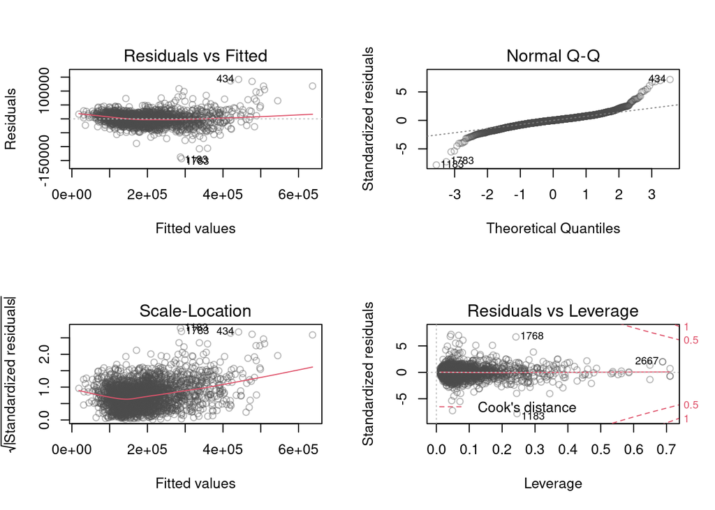

```r
par(mfrow=c(2,2))
plot(fit, col = point.col)
```

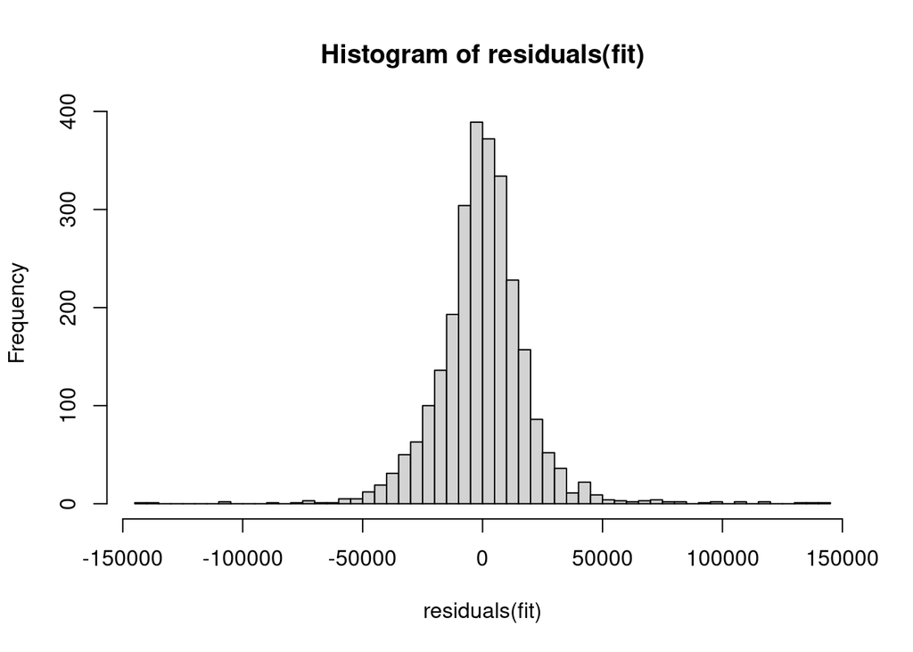

```r
hist(residuals(fit), breaks=50)
```

```r
formula(fit)
```

```
## SalePrice ~ MS.SubClass + MS.Zoning + Lot.Area + Street + Lot.Shape +
##     Land.Contour + Lot.Config + Land.Slope + Neighborhood + Condition.1 +
##     Condition.2 + Bldg.Type + House.Style + Overall.Qual + Overall.Cond +
##     Year.Built + Year.Remod.Add + Roof.Style + Roof.Matl + Exterior.1st +
##     Exterior.2nd + Mas.Vnr.Type + Mas.Vnr.Area + Exter.Qual +
##     Exter.Cond + Foundation + Bsmt.Qual + Bsmt.Cond + Bsmt.Exposure +
##     BsmtFin.Type.1 + BsmtFin.SF.1 + BsmtFin.Type.2 + BsmtFin.SF.2 +
##     Bsmt.Unf.SF + Heating + Heating.QC + Central.Air + Electrical +
##     X1st.Flr.SF + X2nd.Flr.SF + Low.Qual.Fin.SF + Bsmt.Full.Bath +
##     Bsmt.Half.Bath + Full.Bath + Half.Bath + Bedroom.AbvGr +
##     Kitchen.AbvGr + Kitchen.Qual + TotRms.AbvGrd + Functional +
##     Fireplaces + Garage.Type + Garage.Yr.Blt + Garage.Finish +
##     Garage.Cars + Garage.Area + Garage.Qual + Garage.Cond + Paved.Drive +
##     Wood.Deck.SF + Open.Porch.SF + Enclosed.Porch + X3Ssn.Porch +
##     Screen.Porch + Pool.Area + Misc.Val + Mo.Sold + Yr.Sold +
##     Sale.Type + Sale.Condition
```

Keep in mind:

- I think this is the most complicated model we can have (as a linear unweighted least squares model, in terms of RSS), while doing the least data cleaning.
- We will perform model selection starting from here and stepping backwards, and then go the other way around.
- As it is apparent from the Q-Q plot and the histogram of the residuals, the residuals are not normally distributed. Will this also be the case for the simpler model?
- It will also be interesting to investigate how inference results are affected (assuming normality), by comparing them to their bootstrap-obtained counterparts.

# Variable selection - Bringing down the complexity of the model

```r
fit.sub <- step(fit, direction="both")
```

```
## Start:  AIC=52849.04
## SalePrice ~ MS.SubClass + MS.Zoning + Lot.Area + Street + Lot.Shape +
##     Land.Contour + Lot.Config + Land.Slope + Neighborhood + Condition.1 +
##     Condition.2 + Bldg.Type + House.Style + Overall.Qual + Overall.Cond +
##     Year.Built + Year.Remod.Add + Roof.Style + Roof.Matl + Exterior.1st +
##     Exterior.2nd + Mas.Vnr.Type + Mas.Vnr.Area + Exter.Qual +
##     Exter.Cond + Foundation + Bsmt.Qual + Bsmt.Cond + Bsmt.Exposure +
##     BsmtFin.Type.1 + BsmtFin.SF.1 + BsmtFin.Type.2 + BsmtFin.SF.2 +
##     Bsmt.Unf.SF + Heating + Heating.QC + Central.Air + Electrical +
##     X1st.Flr.SF + X2nd.Flr.SF + Low.Qual.Fin.SF + Bsmt.Full.Bath +
##     Bsmt.Half.Bath + Full.Bath + Half.Bath + Bedroom.AbvGr +
##     Kitchen.AbvGr + Kitchen.Qual + TotRms.AbvGrd + Functional +
##     Fireplaces + Garage.Type + Garage.Yr.Blt + Garage.Finish +
##     Garage.Cars + Garage.Area + Garage.Qual + Garage.Cond + Paved.Drive +
##     Wood.Deck.SF + Open.Porch.SF + Enclosed.Porch + X3Ssn.Porch +
##     Screen.Porch + Pool.Area + Misc.Val + Mo.Sold + Yr.Sold +
##     Sale.Type + Sale.Condition
##
##                   Df  Sum of Sq        RSS   AIC
## - Exterior.2nd    13 5.7408e+09 1.0032e+12 52838
## - Bsmt.Cond        3 3.7122e+08 9.9782e+11 52844
## - Lot.Shape        3 5.3388e+08 9.9799e+11 52844
## - Electrical       3 5.5657e+08 9.9801e+11 52845
## - Garage.Type      5 2.1747e+09 9.9963e+11 52845
## - Paved.Drive      2 1.7487e+08 9.9763e+11 52846
## - Heating          2 3.4411e+08 9.9780e+11 52846
## - X3Ssn.Porch      1 1.9802e+06 9.9746e+11 52847
## - Central.Air      1 3.6871e+07 9.9749e+11 52847
## - Bsmt.Half.Bath   1 6.1919e+07 9.9752e+11 52847
## - Garage.Yr.Blt    1 6.8916e+07 9.9752e+11 52847
## - House.Style      7 4.6876e+09 1.0021e+12 52847
## - Heating.QC       4 2.4307e+09 9.9988e+11 52848
## - Misc.Val         1 2.9890e+08 9.9775e+11 52848
## - Half.Bath        1 3.2097e+08 9.9777e+11 52848
## - TotRms.AbvGrd    1 3.5334e+08 9.9781e+11 52848
## - Mo.Sold          1 3.9514e+08 9.9785e+11 52848
## - Full.Bath        1 4.1775e+08 9.9787e+11 52848
## - Open.Porch.SF    1 5.2525e+08 9.9798e+11 52848
## - Bsmt.Full.Bath   1 6.7567e+08 9.9813e+11 52849
## <none>                          9.9745e+11 52849
```

[output cut: 1633 more lines]

```
## - Functional       5 2.1572e+10 1.0335e+12 52843
## - Bsmt.Unf.SF      1 1.9728e+10 1.0316e+12 52846
## - Year.Built       1 2.4669e+10 1.0366e+12 52859
## - Bsmt.Qual        4 2.7934e+10 1.0398e+12 52861
## - Mas.Vnr.Area     1 2.6533e+10 1.0384e+12 52864
## - Exter.Qual       3 3.0106e+10 1.0420e+12 52869
## - Kitchen.Qual     3 3.2720e+10 1.0446e+12 52876
## - Bsmt.Exposure    4 3.4295e+10 1.0462e+12 52878
## - Overall.Qual     1 4.7239e+10 1.0591e+12 52916
## - Lot.Area         1 4.7749e+10 1.0596e+12 52918
## - Overall.Cond     1 5.3213e+10 1.0651e+12 52931
## - BsmtFin.SF.1     1 7.0990e+10 1.0829e+12 52975
## - Neighborhood    25 1.3873e+11 1.1506e+12 53088
## - X1st.Flr.SF      1 1.5912e+11 1.1710e+12 53183
## - X2nd.Flr.SF      1 2.4236e+11 1.2542e+12 53365
```

```r
summary(fit.sub)
```

```
##
## Call:
## lm(formula = SalePrice ~ MS.SubClass + MS.Zoning + Lot.Area +
##     Street + Land.Contour + Lot.Config + Land.Slope + Neighborhood +
##     Condition.1 + Condition.2 + Bldg.Type + House.Style + Overall.Qual +
##     Overall.Cond + Year.Built + Year.Remod.Add + Roof.Style +
##     Roof.Matl + Exterior.1st + Mas.Vnr.Type + Mas.Vnr.Area +
##     Exter.Qual + Exter.Cond + Foundation + Bsmt.Qual + Bsmt.Exposure +
##     BsmtFin.Type.1 + BsmtFin.SF.1 + BsmtFin.Type.2 + BsmtFin.SF.2 +
##     Bsmt.Unf.SF + X1st.Flr.SF + X2nd.Flr.SF + Low.Qual.Fin.SF +
##     Bsmt.Full.Bath + Bedroom.AbvGr + Kitchen.AbvGr + Kitchen.Qual +
##     Functional + Fireplaces + Garage.Finish + Garage.Cars + Garage.Area +
##     Garage.Qual + Garage.Cond + Wood.Deck.SF + Enclosed.Porch +
##     Screen.Porch + Pool.Area + Yr.Sold + Sale.Type + Sale.Condition,
##     data = ames)
##
## Residuals:
##     Min      1Q  Median      3Q     Max
## -142451   -9384     216    9562  147357
##
## Coefficients:
##                         Estimate Std. Error t value Pr(>|t|)
## (Intercept)            3.398e+04  6.375e+05   0.053 0.957500
## MS.SubClass           -8.330e+01  5.019e+01  -1.660 0.097109 .
## MS.ZoningFV            2.358e+04  8.166e+03   2.888 0.003913 **
## MS.ZoningRH            2.183e+04  8.591e+03   2.540 0.011131 *
## MS.ZoningRL            1.930e+04  7.233e+03   2.669 0.007668 **
## MS.ZoningRM            1.233e+04  6.839e+03   1.803 0.071569 .
## Lot.Area               7.979e-01  7.367e-02  10.831  < 2e-16 ***
## StreetPave             2.625e+04  8.448e+03   3.107 0.001910 **
## Land.ContourHLS        6.017e+03  3.174e+03   1.896 0.058097 .
## Land.ContourLow       -1.178e+04  4.209e+03  -2.799 0.005173 **
## Land.ContourLvl        8.135e+02  2.406e+03   0.338 0.735349
## Lot.ConfigCulDSac      5.091e+03  1.969e+03   2.585 0.009790 **
## Lot.ConfigFR2         -4.565e+03  2.666e+03  -1.712 0.086975 .
## Lot.ConfigFR3         -1.557e+03  5.870e+03  -0.265 0.790834
## Lot.ConfigInside       1.146e+03  1.104e+03   1.038 0.299544
## Land.SlopeMod          4.171e+03  2.481e+03   1.681 0.092821 .
## Land.SlopeSev         -3.945e+04  7.680e+03  -5.136 3.02e-07 ***
## NeighborhoodBlueste    4.164e+03  8.420e+03   0.495 0.620975
```

[output cut: 142 more lines]

```
## Sale.TypeCWD           1.035e+04  6.461e+03   1.601 0.109424
## Sale.TypeNew           1.273e+04  9.307e+03   1.368 0.171429
## Sale.TypeOth           2.596e+04  1.052e+04   2.467 0.013692 *
## Sale.TypeWD            2.423e+03  2.562e+03   0.946 0.344441
## Sale.ConditionAdjLand  2.860e+04  8.872e+03   3.224 0.001282 **
## Sale.ConditionAlloca   1.175e+04  6.450e+03   1.821 0.068727 .
## Sale.ConditionFamily   2.573e+03  3.574e+03   0.720 0.471624
## Sale.ConditionNormal   7.392e+03  1.898e+03   3.894 0.000101 ***
## Sale.ConditionPartial  7.475e+03  8.987e+03   0.832 0.405623
## ---
## Signif. codes:  0 '***' 0.001 '**' 0.01 '*' 0.05 '.' 0.1 ' ' 1
##
## Residual standard error: 20180 on 2486 degrees of freedom
## Multiple R-squared:  0.9386, Adjusted R-squared:  0.9344
## F-statistic:   226 on 168 and 2486 DF,  p-value: < 2.2e-16
```

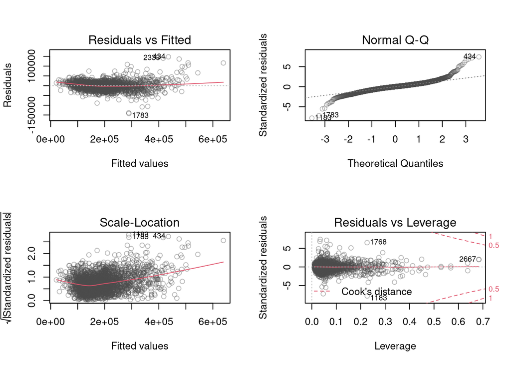

```r
par(mfrow=c(2,2))
plot(fit.sub, col = point.col)
```

## Forward search starting from a simple model

```r
fit2 <- lm('SalePrice ~ 1', ames)
```

```r
fit2.sub <- step(fit2, direction="both", scope=formula(fit))
```

```
## Start:  AIC=59867.41
## SalePrice ~ 1
##
##                   Df  Sum of Sq        RSS   AIC
## + Overall.Qual     1 1.0472e+13 5.9952e+12 57187
## + Neighborhood    25 9.2303e+12 7.2366e+12 57734
## + Bsmt.Qual        4 8.3840e+12 8.0830e+12 57986
## + Exter.Qual       3 8.3400e+12 8.1270e+12 57999
## + Kitchen.Qual     3 7.9789e+12 8.4881e+12 58114
## + X1st.Flr.SF      1 7.1288e+12 9.3381e+12 58363
## + Garage.Cars      1 7.0749e+12 9.3920e+12 58379
## + Garage.Area      1 6.7711e+12 9.6959e+12 58463
## + Full.Bath        1 5.1924e+12 1.1275e+13 58864
## + Year.Built       1 4.9288e+12 1.1538e+13 58925
## + TotRms.AbvGrd    1 4.7287e+12 1.1738e+13 58971
## + Garage.Yr.Blt    1 4.5902e+12 1.1877e+13 59002
## + Year.Remod.Add   1 4.5753e+12 1.1892e+13 59005
## + Garage.Finish    2 4.4862e+12 1.1981e+13 59027
## + Foundation       4 4.4984e+12 1.1969e+13 59028
## + Mas.Vnr.Area     1 4.3864e+12 1.2081e+13 59047
## + BsmtFin.Type.1   5 3.5339e+12 1.2933e+13 59236
## + Garage.Type      5 3.4669e+12 1.3000e+13 59250
## + Fireplaces       1 3.3979e+12 1.3069e+13 59256
## + Heating.QC       4 3.3934e+12 1.3074e+13 59263
## + Mas.Vnr.Type     3 3.0942e+12 1.3373e+13 59321
## + BsmtFin.SF.1     1 2.9441e+12 1.3523e+13 59346
## + Exterior.1st    11 2.9343e+12 1.3533e+13 59368
## + Bsmt.Exposure    4 2.8136e+12 1.3653e+13 59378
## + Exterior.2nd    13 2.8809e+12 1.3586e+13 59383
## + Sale.Type        8 2.2989e+12 1.4168e+13 59484
## + Sale.Condition   5 2.2181e+12 1.4249e+13 59493
## + Open.Porch.SF    1 1.7705e+12 1.4696e+13 59567
## + MS.Zoning        4 1.7317e+12 1.4735e+13 59580
## + Wood.Deck.SF     1 1.5922e+12 1.4875e+13 59599
## + Lot.Shape        3 1.3974e+12 1.5070e+13 59638
## + Roof.Style       5 1.3548e+12 1.5112e+13 59649
## + Lot.Area         1 1.2420e+12 1.5225e+13 59661
## + Half.Bath        1 1.2010e+12 1.5266e+13 59668
## + House.Style      7 1.2613e+12 1.5206e+13 59670
## + X2nd.Flr.SF      1 1.1397e+12 1.5327e+13 59679
```

[output cut: 4252 more lines]

```
## - Functional       5 2.1572e+10 1.0335e+12 52843
## - Bsmt.Unf.SF      1 1.9728e+10 1.0316e+12 52846
## - Year.Built       1 2.4669e+10 1.0366e+12 52859
## - Bsmt.Qual        4 2.7934e+10 1.0398e+12 52861
## - Mas.Vnr.Area     1 2.6533e+10 1.0384e+12 52864
## - Exter.Qual       3 3.0106e+10 1.0420e+12 52869
## - Kitchen.Qual     3 3.2720e+10 1.0446e+12 52876
## - Bsmt.Exposure    4 3.4295e+10 1.0462e+12 52878
## - Overall.Qual     1 4.7239e+10 1.0591e+12 52916
## - Lot.Area         1 4.7749e+10 1.0596e+12 52918
## - Overall.Cond     1 5.3213e+10 1.0651e+12 52931
## - BsmtFin.SF.1     1 7.0990e+10 1.0829e+12 52975
## - Neighborhood    25 1.3873e+11 1.1506e+12 53088
## - X1st.Flr.SF      1 1.5912e+11 1.1710e+12 53183
## - X2nd.Flr.SF      1 2.4236e+11 1.2542e+12 53365
```

Even though the covariates are in different order, we have in fact converged to the same solution as with the backwards elimination.

```r
p1 <- sort(names(fit2.sub$coefficients))
p2 <- sort(names(fit.sub$coefficients))
for (i in 1:length(p1)) {
  cat(p1[i] == p2[i], ' ')
}
```

```
## TRUE  TRUE  TRUE  TRUE  TRUE  TRUE  TRUE  TRUE  TRUE  TRUE  TRUE  TRUE  TRUE  TRUE  TRUE  TRUE  TRUE  TRUE  TRUE  TRUE  TRUE  TRUE  TRUE  TRUE  TRUE  TRUE  TRUE  TRUE  TRUE  TRUE  TRUE  TRUE  TRUE  TRUE  TRUE  TRUE  TRUE  TRUE  TRUE  TRUE  TRUE  TRUE  TRUE  TRUE  TRUE  TRUE  TRUE  TRUE  TRUE  TRU…
```